# CommitOverTime

# Load Libraries

```r
#install.packages("dplyr")
#install.packages("stringr")
#nstall.packages(graphics)
#install.packages("lubridate")
# load installed libraries
library(dplyr)
library(stringr)
library(graphics)
library(ggplot2)
library(lubridate)
```

Festlegen der Zeitspanne

```r
timeframe <- c(as.Date("1997-01-01"),as.Date("2019-12-31"))
```

# PostgreSQL

Einlesen der Daten aus dem CSV sowie umwandeln der Zeitdaten in ein R Zeitformat

```r
#Load function to import db_history .csv file
#usage: load_db_history("path")
source("../csv_file_import/load_db_history2.R")
db_git_history_Postgre = load_db_history2(input_path = "../../Workspace/histories/PostgreSQL.csv")
db_git_history_Postgre["timestamp"] = lapply(db_git_history_Postgre["timestamp"],function(x) as.Date(x, format='%Y-%m-%d') )
```

Anziegen der Files mit den meisten Commits

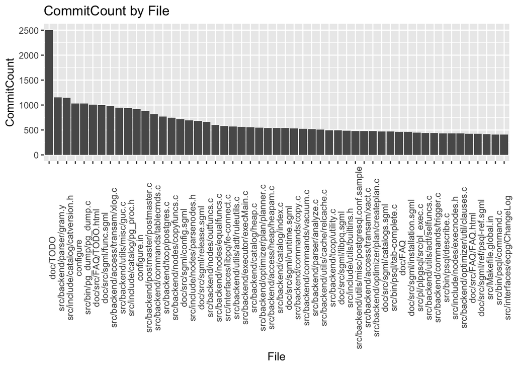

```r
extractedTable_Postgre_CommitCountByFile <- db_git_history_Postgre %>%
  group_by(file) %>%
    summarise(commitCount = n_distinct(commit)) %>%
  filter(.,commitCount>400)


ggplot(extractedTable_Postgre_CommitCountByFile, aes(x=reorder(file,-commitCount),y =commitCount)) + geom_col()+theme(axis.text.x = element_text(angle = 90)) +ggtitle("CommitCount by File") +
            xlab("File") + ylab("CommitCount")
```

#HotSpot auswertung

```r
db_git_history_Postgre %>%
  group_by(programmingLanguage)%>%
  summarise(n = n())%>%
  arrange(desc(n))
```

```
## # A tibble: 30 x 2
##    programmingLanguage      n
##    <fct>                <int>
##  1 C                   147907
##  2 unkown               69800
##  3 PLSQL                 5960
##  4 Perl                  3276
##  5 Yacc                  2054
##  6 Java                  2003
##  7 Common Lisp           1491
##  8 Makefile               990
##  9 Shell                  857
## 10 M4                     354
## # … with 20 more rows
```

Wie Hoch ist der Anteil einer Programmiersprache in einem Repository

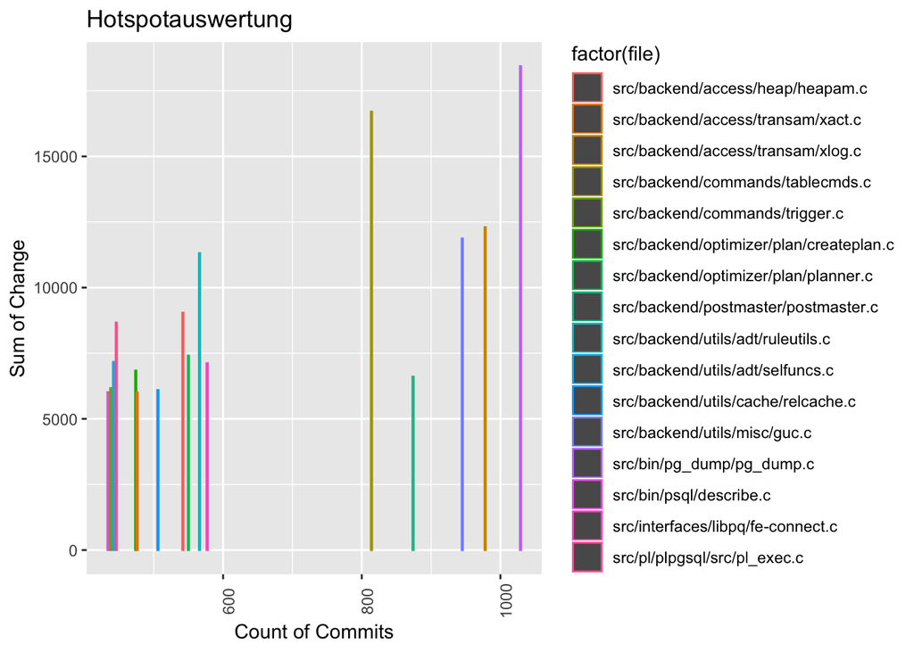

```r
extractedTable_Postgre_SumOfChangeByFile <- db_git_history_Postgre %>%
  group_by(file,programmingLanguage) %>%
    summarise(sumOfChange = sum(change)) %>%
  filter(str_detect(programmingLanguage, "C")) %>%
  arrange(desc(sumOfChange)) %>%
  head(25)

hotspot_postgre <-extractedTable_Postgre_CommitCountByFile %>%
  inner_join(extractedTable_Postgre_SumOfChangeByFile,by="file")

ggplot(hotspot_postgre, aes(x=commitCount,y =sumOfChange,colour = factor(file))) + geom_col()+theme(axis.text.x = element_text(angle = 90))+ggtitle("Hotspotauswertung") +
            xlab("Count of Commits") + ylab("Sum of Change")
```

Gruppiert nach Datum werden die eindeutigen CommitIds für diesen Tag aufsummiert

```r
extractedTable_Postgre <- db_git_history_Postgre %>%
  group_by(timestamp) %>%
    summarise(commitCount = n_distinct(commit))
```

Plot zum Überblick

```r
PostgrePlot <-ggplot(extractedTable_Postgre, aes(y=commitCount,x=timestamp)) + geom_line(color = "green") +stat_smooth(
  color = "#FC4E07", fill = "#FC4E07",
  method = "loess"
  )+ggtitle("Commit over Time") +
            xlab("Date") + ylab("CommitCount") + scale_x_date(limit=timeframe)
```

Hier lässt sich erkennen das zu beginn der erstellung des Repository zunächst viel Code Produziert wird, anschließend fällt die Commitanzahl leicht ab um dann wieder leicht anzusteigen.

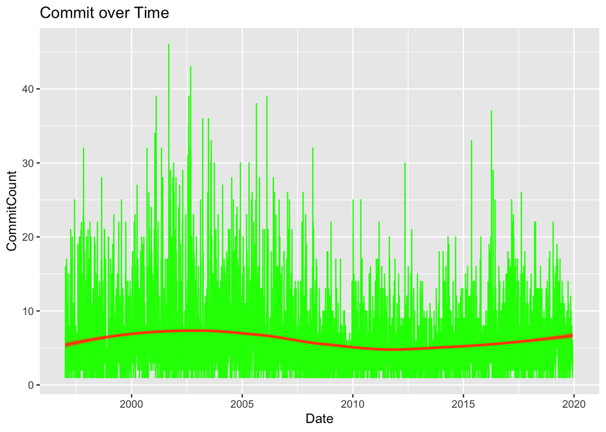

```r
PostgrePlot
```

Erzeugen einer extra Spalte für Monat und Jahr

```r
extractedTable_Postgre$month = month(extractedTable_Postgre$timestamp)
extractedTable_Postgre$year = year(extractedTable_Postgre$timestamp)
```

Erneutes aufsummieren der Commits pro Monat

```r
extractedTableMonth_Postgre <- extractedTable_Postgre %>%
  group_by(year,month) %>%
    summarise(commits = sum(commitCount))
```

Weiterer Plot als Monatsübersicht.

```r
PostgrePlotMonthly <-ggplot(extractedTableMonth_Postgre, aes(y=commits,x=year,month)) +
  geom_smooth() +ggtitle("Commits over Time Postgre") +
            xlab("Time") + ylab("Commits")
```

Hier kann man das Abfallen der Commitanzahl bereits besser erkennen

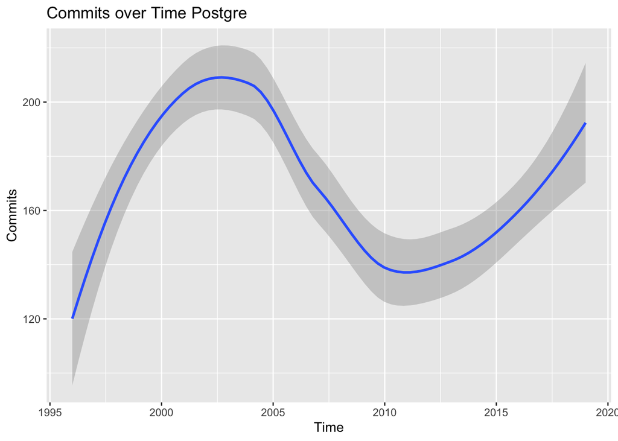

```r
PostgrePlotMonthly
```

Zum Abschluss noch eine Einzelauflistung der jeweiligen Jahre

```r
PostgrePlotMonthlyFacet <- ggplot(extractedTableMonth_Postgre, aes(y=commits,x=month)) +
      geom_bar(stat = "identity", fill = "darkorchid4") +
  facet_wrap(~ year, ncol = 5) +ggtitle("Commit over Time") +
            xlab("Time") + ylab("Commits")
```

Auch hier mit der selben Erkenntnis

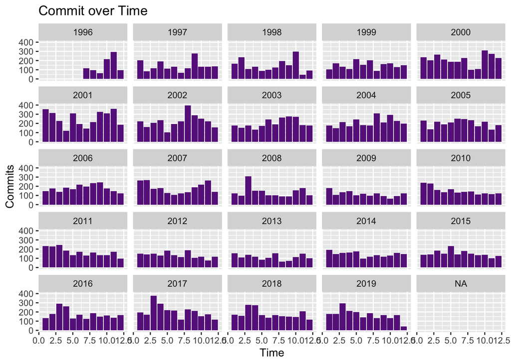

```r
PostgrePlotMonthlyFacet
```

# MySQL Die Einlese- und Bearbeitungsmethoden sind gleich

```r
db_git_history_MySQL = load_db_history2(input_path = "../../Workspace/histories/MySQL.csv")
db_git_history_MySQL["timestamp"] = lapply(db_git_history_MySQL["timestamp"], function(x) as.Date(x, format='%Y-%m-%d'))
```

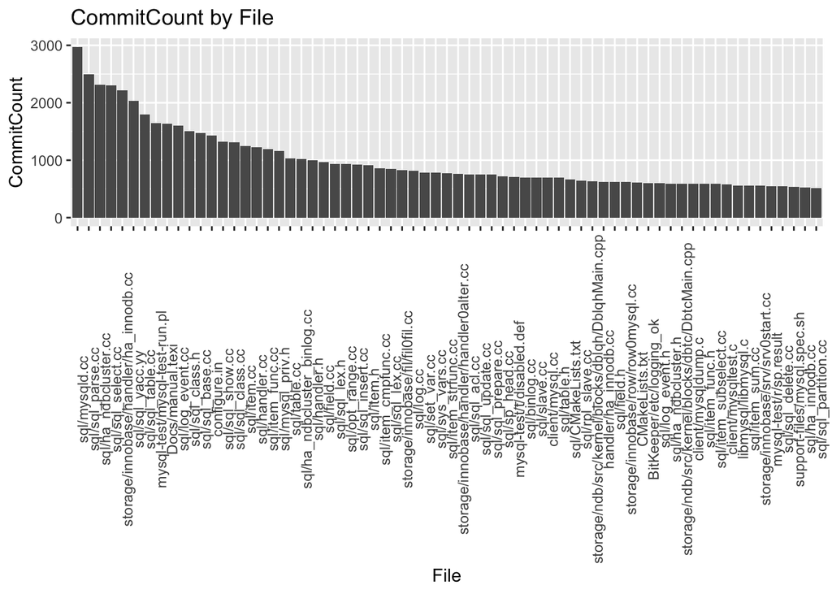

```r
extractedTable_MySQL_CommitCountByFile <- db_git_history_MySQL %>%
  group_by(file) %>%
    summarise(commitCount = n_distinct(commit)) %>%
  filter(.,commitCount>500)


ggplot(extractedTable_MySQL_CommitCountByFile, aes(x=reorder(file,-commitCount),y =commitCount)) + geom_col()+theme(axis.text.x = element_text(angle = 90))+ggtitle("CommitCount by File") +
            xlab("File") + ylab("CommitCount")
```

HotSpot auswertung

```r
db_git_history_MySQL %>%
  group_by(programmingLanguage)%>%
  summarise(n = n())%>%
  arrange(desc(n))
```

```
## # A tibble: 50 x 2
##    programmingLanguage      n
##    <fct>                <int>
##  1 unkown              286925
##  2 C++                 184914
##  3 C                   124401
##  4 JavaScript           11372
##  5 Assembly              9385
##  6 Java                  7198
##  7 Jasmin                5290
##  8 Perl                  4527
##  9 Shell                 3917
## 10 CMake                 2619
## # … with 40 more rows
```

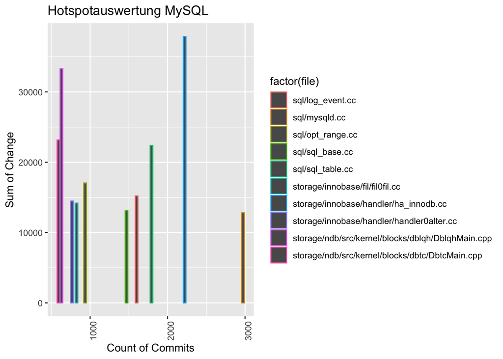

```r
extractedTable_MySQL_SumOfChangeByFile <- db_git_history_MySQL %>%
  group_by(file,programmingLanguage) %>%
    summarise(sumOfChange = sum(change)) %>%
  filter(str_detect(programmingLanguage, "C++")) %>%
  arrange(desc(sumOfChange)) %>%
  head(25)

hotspot_MySQL <-extractedTable_MySQL_CommitCountByFile %>%
  inner_join(extractedTable_MySQL_SumOfChangeByFile,by="file")

ggplot(hotspot_MySQL, aes(x=commitCount,y =sumOfChange,colour = factor(file))) + geom_col()+theme(axis.text.x = element_text(angle = 90))+ggtitle("Hotspotauswertung MySQL") +
            xlab("Count of Commits") + ylab("Sum of Change")
```

```r
extractedTable_MySQL <- db_git_history_MySQL %>%
  group_by(timestamp) %>%
    summarise(commitCount = n_distinct(commit))


MySQLPlot <-ggplot(extractedTable_MySQL, aes(y=commitCount,x=timestamp)) + geom_line(color = "green") +stat_smooth(
  color = "#FC4E07", fill = "#FC4E07",
  method = "loess"
  )+ggtitle("Commit over Time") +
            xlab("Date") + ylab("CommitCount") + scale_x_date(limit=timeframe)
```

Auch bei MySQL steigt zu beginn die Commitzahl an und fällt später wieder ab wobei hier insgesamt mehr Commits gemacht werden

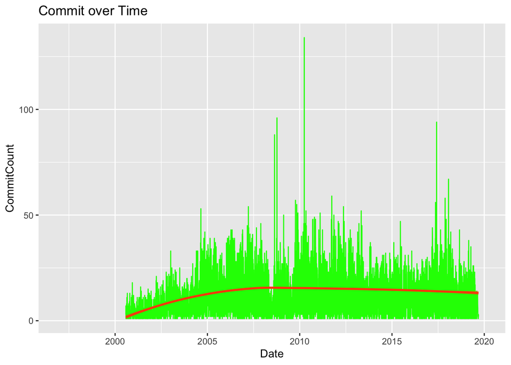

```r
MySQLPlot
```

```r
extractedTable_MySQL$month = month(extractedTable_MySQL$timestamp)
extractedTable_MySQL$year = year(extractedTable_MySQL$timestamp)

extractedTableMonth_MySQL <- extractedTable_MySQL %>%
  group_by(month,year) %>%
    summarise(commits = sum(commitCount))

MySQLPlotMonthly <-ggplot(extractedTableMonth_MySQL, aes(y=commits,x=year,month)) +
  geom_smooth() +ggtitle("Commit over Time") +
            xlab("Time") + ylab("Commits")
```

MySQL macht ca doppelt so viel Commits im Manat zur Spitzenzeit

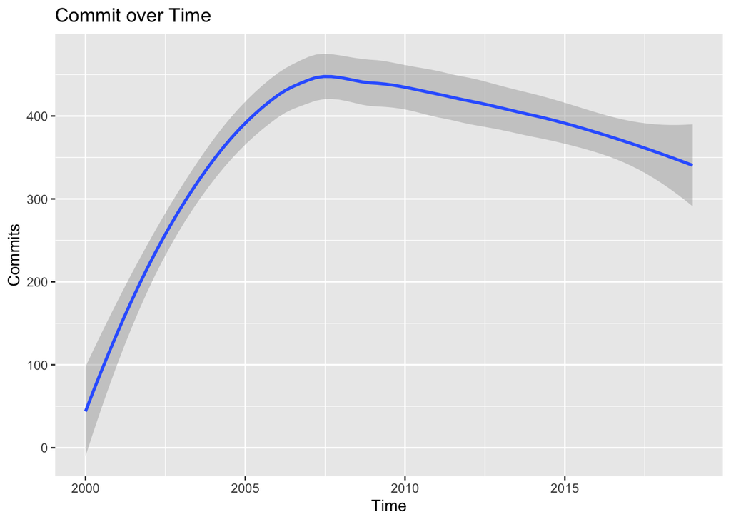

```r
MySQLPlotMonthly
```

```r
MySQLPlotMonthlyFacet <- ggplot(extractedTableMonth_MySQL, aes(y=commits,x=month)) +
      geom_bar(stat = "identity", fill = "darkorchid4") +
  facet_wrap(~ year, ncol = 5)+ggtitle("Commit over Time") +
            xlab("Time") + ylab("Commits")
```

Auch hier lässt sich das Abfallen der Commits beobachten

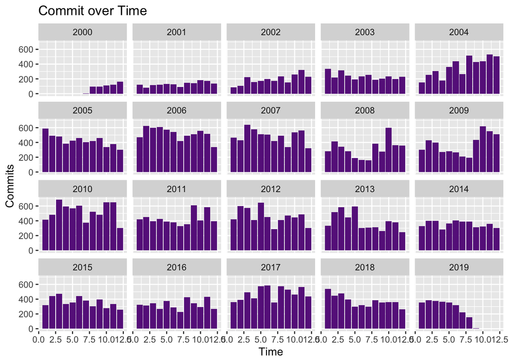

```r
MySQLPlotMonthlyFacet
```

# Mongo

```r
db_git_history_MongoDB = load_db_history2(input_path = "../../Workspace/histories/MongoDB.csv")
db_git_history_MongoDB["timestamp"] = lapply(db_git_history_MongoDB["timestamp"], function(x) as.Date(x, format='%Y-%m-%d'))
```

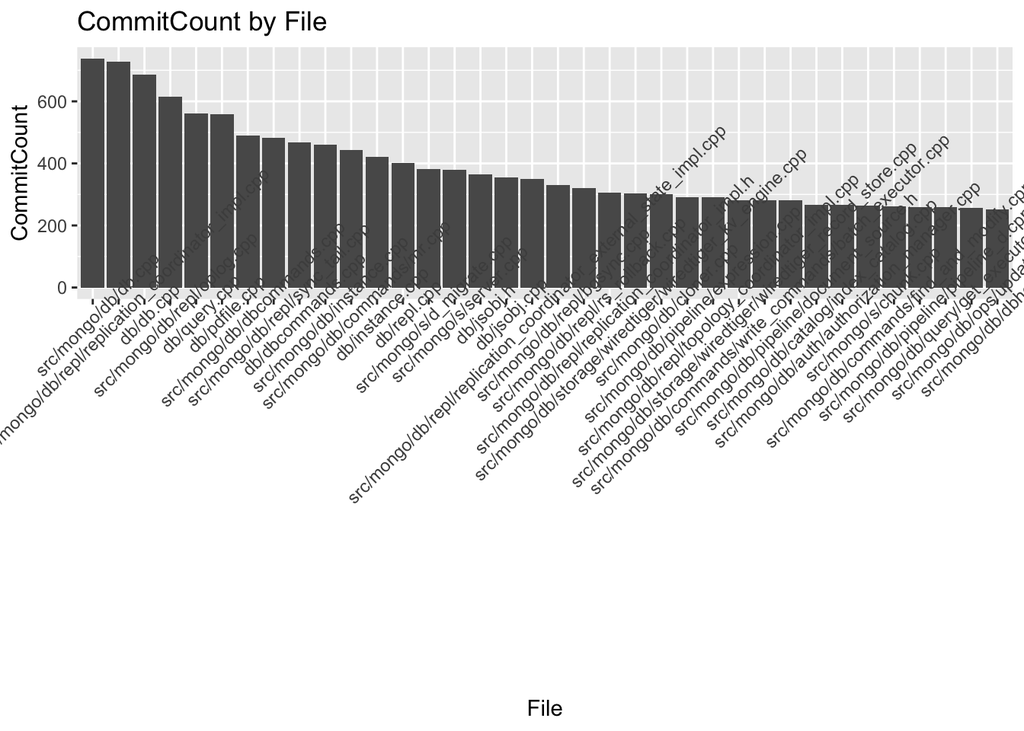

```r
extractedTable_MongoDB_CommitCountByFile <- db_git_history_MongoDB %>%
  group_by(file,programmingLanguage) %>%
    summarise(commitCount = n_distinct(commit)) %>%
  filter(str_detect(programmingLanguage, "C++")) %>%
  filter(.,commitCount>250)


ggplot(extractedTable_MongoDB_CommitCountByFile, aes(x=reorder(file,-commitCount),y =commitCount)) + geom_col()+theme(axis.text.x = element_text( angle = 45))+ggtitle("CommitCount by File") +
            xlab("File") + ylab("CommitCount")
```

HotSpot auswertung

```r
db_git_history_MongoDB %>%
  group_by(programmingLanguage)%>%
  summarise(n = n())%>%
  arrange(desc(n))
```

```
## # A tibble: 28 x 2
##    programmingLanguage          n
##    <fct>                    <int>
##  1 C++                     143160
##  2 unkown                   95862
##  3 C                        73479
##  4 JavaScript               43333
##  5 Python                    7780
##  6 Go                        1148
##  7 Shell                      433
##  8 Java                       286
##  9 GCC Machine Description    200
## 10 M4                         102
## # … with 18 more rows
```

```r
extractedTable_MongoDB_SumOfChangeByFile <- db_git_history_MongoDB %>%
  group_by(file,programmingLanguage) %>%
    summarise(sumOfChange = sum(change)) %>%
  filter(str_detect(programmingLanguage, "C++")) %>%
  arrange(desc(sumOfChange)) %>%
  head(30)

hotspot_MongoDB <-extractedTable_MongoDB_CommitCountByFile %>%
  inner_join(extractedTable_MongoDB_SumOfChangeByFile,by="file")
hotspot_MongoDB
```

```
## # A tibble: 1 x 5
## # Groups:   file [1]
##   file          programmingLangu… commitCount programmingLangu… sumOfChange
##   <fct>         <fct>                   <int> <fct>                   <int>
## 1 src/mongo/db… C++                       291 C++                      6465
```

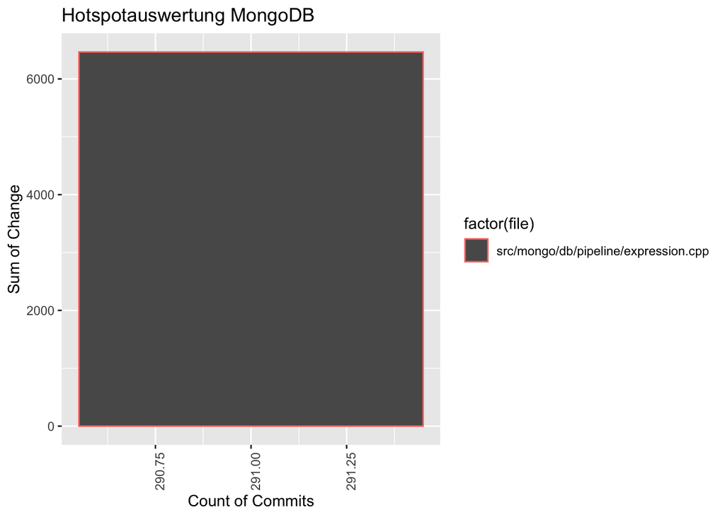

```r
ggplot(hotspot_MongoDB, aes(x=commitCount,y =sumOfChange,colour = factor(file))) + geom_col()+theme(axis.text.x = element_text(angle = 90))+ggtitle("Hotspotauswertung MongoDB") +
            xlab("Count of Commits") + ylab("Sum of Change")
```

```r
extractedTable_MongoDB <- db_git_history_MongoDB %>%
  group_by(timestamp) %>%
    summarise(commitCount = n_distinct(commit))



MongoDB <-ggplot(extractedTable_MongoDB, aes(y=commitCount,x=timestamp)) + geom_line(color = "green") +stat_smooth(
  color = "#FC4E07", fill = "#FC4E07",
  method = "loess"
  )+ggtitle("Commit over Time") +
            xlab("Date") + ylab("CommitCount") + scale_x_date(limit=timeframe)
```

Bei MongoDb anders als bei den anderen steigt nach einer kurzen abnahme die Commitanzahl leicht bis heute

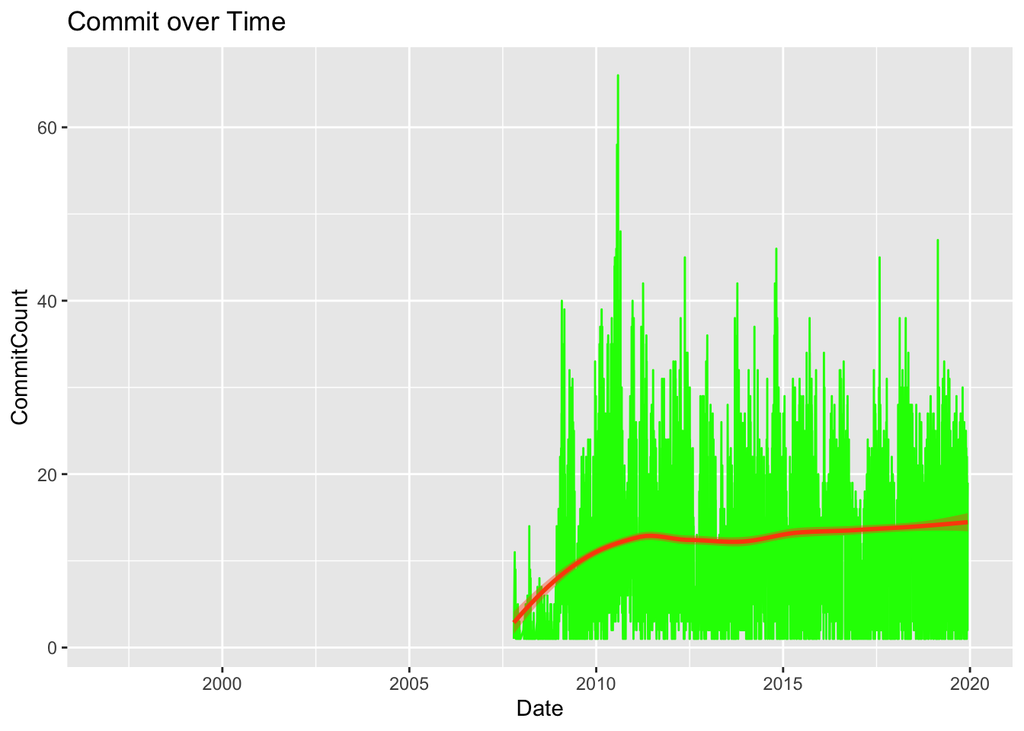

```r
MongoDB
```

```r
extractedTable_MongoDB$month = month(extractedTable_MongoDB$timestamp)
extractedTable_MongoDB$year = year(extractedTable_MongoDB$timestamp)

extractedTableMonth_MongoDB <- extractedTable_MongoDB %>%
  group_by(month,year) %>%
    summarise(commits = sum(commitCount))



MongoDBPlotMonthly <-ggplot(extractedTableMonth_MongoDB, aes(y=commits,x=year,month)) +
  geom_smooth()
```

Die Spitze ist ähnlich hoch wie bei MySQL

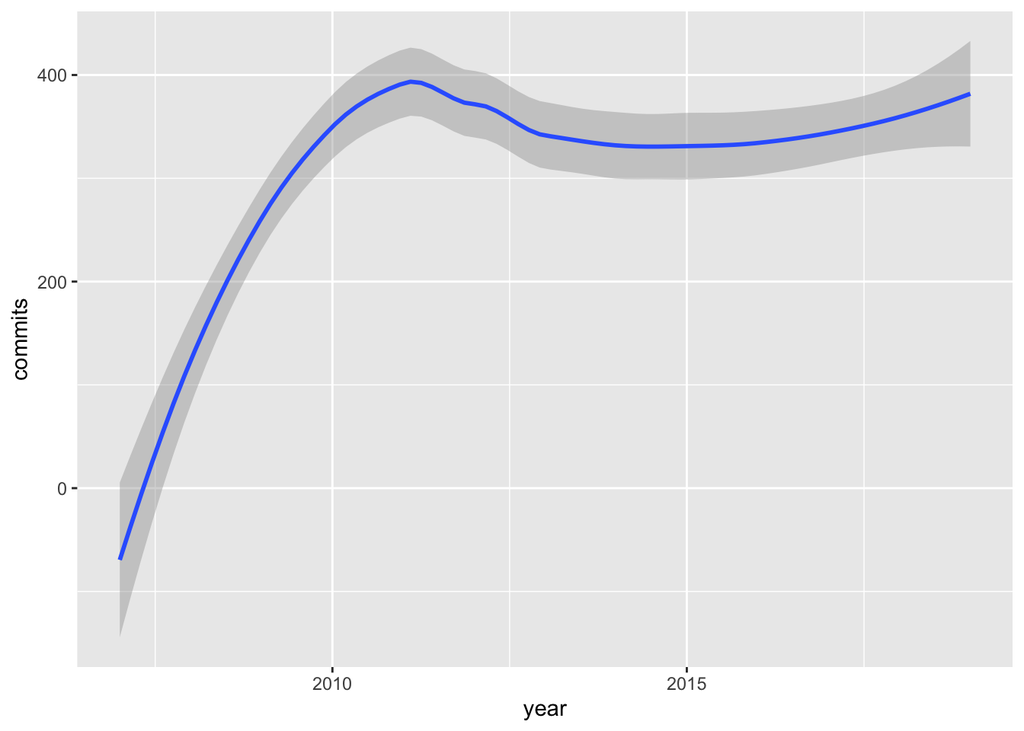

```r
MongoDBPlotMonthly
```

```r
MongoDBPlotMonthlyFacet <- ggplot(extractedTableMonth_MongoDB, aes(y=commits,x=month)) +
      geom_bar(stat = "identity", fill = "darkorchid4") +
  facet_wrap(~ year, ncol = 5)
```

Die Spitze lässt sich hier nur schwer erkennen

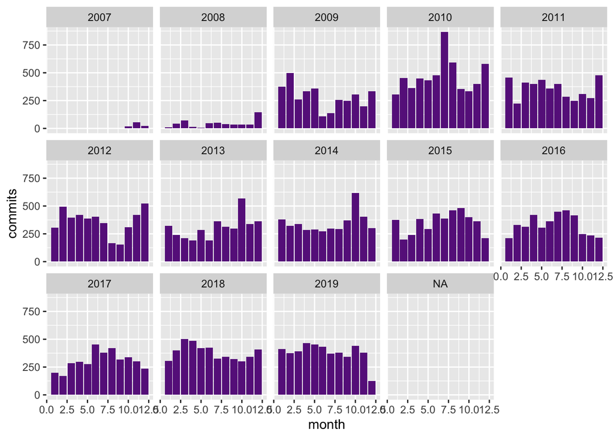

```r
MongoDBPlotMonthlyFacet
```